# Sales Pitch Final Project DDP: FOREX Currency Converter Shiny App

jc

8/10/2020

# Introduction

The foreign exchange market (Forex) is a global non-centralized market for trading currencies. The dynamics of this market automatically determine the **foreign exchange rates** for all currencies. It is actually the largest market in the world of trading. An foreign exchange rate (FER) is the amount of change that one currency will be exchanged for another [[1]](https://en.wikipedia.org/wiki/Exchange_rate). In other words, it is the value of one country’s currency in relation to another currency. However, despite of many skeptiscim by many world renamed economists the exchange rates can be changed by each country authority. It is very important to keep track of the changes that different currencies are taking in real time in order to perform a good trading task. Moreover, historical Data about currency exchange rates is the basis for making FOREX analysis and perhaps predictions.

In this shyny app we show different currency exchange rates accross time for many countries. The Data was obtained using a dataset from the [Federal Reserve Bank of Saint Louis](https://fred.stlouisfed.org) that was stored at https://datahub.io/core/exchange-rates.

This app can be found at: https://cordero.shinyapps.io/FOREXAPP/

# The Application

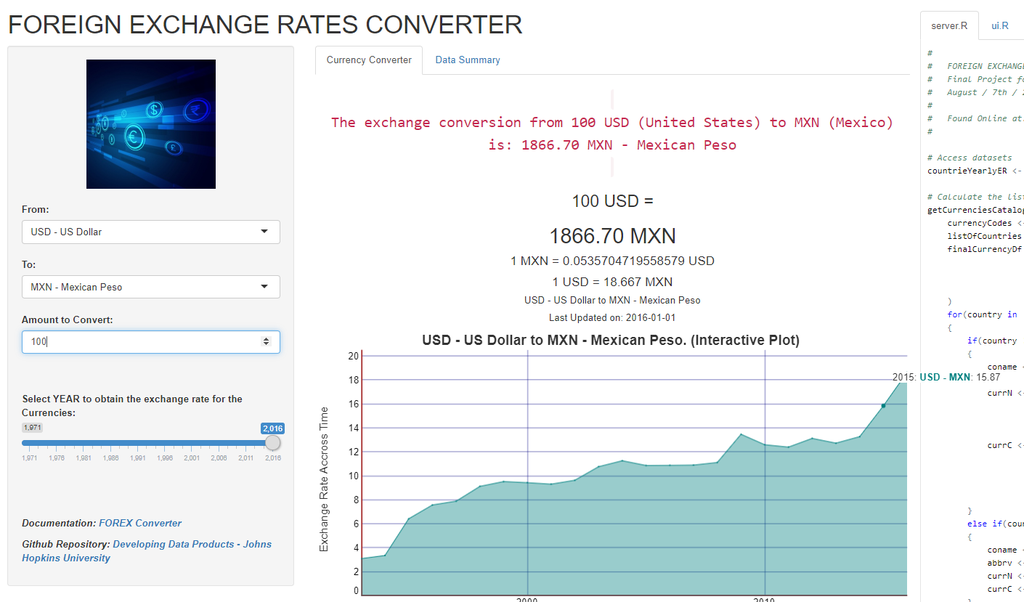

Shiny App

The github repository for the shiny app is in https://github.com/corderoai/DDPJHU_Final_Project_ShinyApp.

# Time Series of Currency Conversion Rates (Interactive)

```r
countrieYearlyER <- read.csv("./data/yearly_csv.csv")
```

[interactive chart not shown]

This plot was made with R code (dygrpahs package) with echo = FALSE.

# Some Tables

|  | USD | MXN |
| --- | --- | --- |
| 1 | 1.00 USD | 18.67 MXN |
| 2 | 5.00 USD | 93.34 MXN |
| 3 | 10.00 USD | 186.67 MXN |
| 4 | 25.00 USD | 466.68 MXN |
| 5 | 50.00 USD | 933.35 MXN |
| 6 | 100.00 USD | 1866.70 MXN |
| 7 | 500.00 USD | 9333.50 MXN |
| 8 | 1000.00 USD | 18667.00 MXN |
| 9 | 5000.00 USD | 93335.00 MXN |
| 10 | 10000.00 USD | 186670.00 MXN |

[output cut: 2 more lines]

This table was made with R code with echo = FALSE.